# DATA621_Proj3

sanjivek

July 2, 2016

## Data Exploration:

Analyzing the overall data to see if there is any discrepancies there as missing data or there is any need for data transformation

**Inferential Statistics**

```r
names(crime)
```

```
##  [1] "zn"      "indus"   "chas"    "nox"     "rm"      "age"     "dis"
##  [8] "rad"     "tax"     "ptratio" "black"   "lstat"   "medv"    "target"
```

```r
str(crime)
```

```
## 'data.frame':    466 obs. of  14 variables:
##  $ zn     : num  0 0 0 30 0 0 0 0 0 80 ...
##  $ indus  : num  19.58 19.58 18.1 4.93 2.46 ...
##  $ chas   : int  0 1 0 0 0 0 0 0 0 0 ...
##  $ nox    : num  0.605 0.871 0.74 0.428 0.488 0.52 0.693 0.693 0.515 0.392 ...
##  $ rm     : num  7.93 5.4 6.49 6.39 7.16 ...
##  $ age    : num  96.2 100 100 7.8 92.2 71.3 100 100 38.1 19.1 ...
##  $ dis    : num  2.05 1.32 1.98 7.04 2.7 ...
##  $ rad    : int  5 5 24 6 3 5 24 24 5 1 ...
##  $ tax    : int  403 403 666 300 193 384 666 666 224 315 ...
##  $ ptratio: num  14.7 14.7 20.2 16.6 17.8 20.9 20.2 20.2 20.2 16.4 ...
##  $ black  : num  369 397 387 375 394 ...
##  $ lstat  : num  3.7 26.82 18.85 5.19 4.82 ...
##  $ medv   : num  50 13.4 15.4 23.7 37.9 26.5 5 7 22.2 20.9 ...
##  $ target : int  1 1 1 0 0 0 1 1 0 0 ...
```

```r
dim(crime)
```

```
## [1] 466  14
```

```r
kable(summary(crime))
```

|  | zn | indus | chas | nox | rm | age | dis | rad | tax | ptratio | black | lstat | medv | target |
| --- | --- | --- | --- | --- | --- | --- | --- | --- | --- | --- | --- | --- | --- | --- |
|  | Min. : 0.00 | Min. : 0.460 | Min. :0.00000 | Min. :0.3890 | Min. :3.863 | Min. : 2.90 | Min. : 1.130 | Min. : 1.00 | Min. :187.0 | Min. :12.6 | Min. : 0.32 | Min. : 1.730 | Min. : 5.00 | Min. :0.0000 |
|  | 1st Qu.: 0.00 | 1st Qu.: 5.145 | 1st Qu.:0.00000 | 1st Qu.:0.4480 | 1st Qu.:5.887 | 1st Qu.: 43.88 | 1st Qu.: 2.101 | 1st Qu.: 4.00 | 1st Qu.:281.0 | 1st Qu.:16.9 | 1st Qu.:375.61 | 1st Qu.: 7.043 | 1st Qu.:17.02 | 1st Qu.:0.0000 |
|  | Median : 0.00 | Median : 9.690 | Median :0.00000 | Median :0.5380 | Median :6.210 | Median : 77.15 | Median : 3.191 | Median : 5.00 | Median :334.5 | Median :18.9 | Median :391.34 | Median :11.350 | Median :21.20 | Median :0.0000 |
|  | Mean : 11.58 | Mean :11.105 | Mean :0.07082 | Mean :0.5543 | Mean :6.291 | Mean : 68.37 | Mean : 3.796 | Mean : 9.53 | Mean :409.5 | Mean :18.4 | Mean :357.12 | Mean :12.631 | Mean :22.59 | Mean :0.4914 |
|  | 3rd Qu.: 16.25 | 3rd Qu.:18.100 | 3rd Qu.:0.00000 | 3rd Qu.:0.6240 | 3rd Qu.:6.630 | 3rd Qu.: 94.10 | 3rd Qu.: 5.215 | 3rd Qu.:24.00 | 3rd Qu.:666.0 | 3rd Qu.:20.2 | 3rd Qu.:396.24 | 3rd Qu.:16.930 | 3rd Qu.:25.00 | 3rd Qu.:1.0000 |
|  | Max. :100.00 | Max. :27.740 | Max. :1.00000 | Max. :0.8710 | Max. :8.780 | Max. :100.00 | Max. :12.127 | Max. :24.00 | Max. :711.0 | Max. :22.0 | Max. :396.90 | Max. :37.970 | Max. :50.00 | Max. :1.0000 |

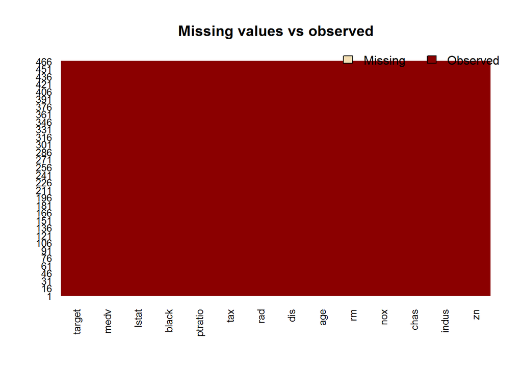

```r
missmap(crime, main = "Missing values vs observed")
```

### We observed that:

- The crime dataset contains 14 variables, with 466 observations
- There are no missing values.
- The Minimum, Quatiles and Maximum values.
- Since this is logistic regression we don’t have to worry about the normal distribution of data and no transformation is needed

## Data Preparation

### For this there is no major data preparation effort is needed as this is a logistic regression and more over there is no missing data in the dataset, so we will try doing a preliminary analysis as plotting LSTAT against Zn

```r
# Why We have done this??

plot_ly(data = crime, x = zn , y = lstat, mode = "markers",
        color = "blue", line = list(shape = "linear"))
```

[interactive chart not shown]

## Build Models

### Consdering target as a response variable (Independent variable), lets pair it with complete data set and also find the best fit model using GLM package

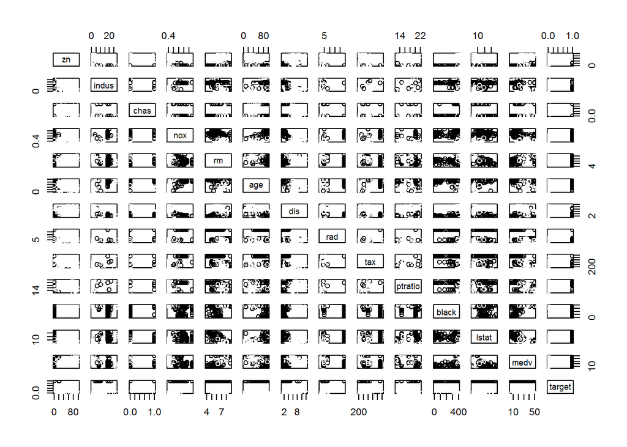

```r
pairs(crime, col=crime$target)
```

```r
fit <- glm(target ~., data = crime)
```

### Summary of the output is as shown below

```r
summary(fit)
```

```
##
## Call:
## glm(formula = target ~ ., data = crime)
##
## Deviance Residuals:
##      Min        1Q    Median        3Q       Max
## -0.58798  -0.21065  -0.04792   0.14512   0.88772
##
## Coefficients:
##               Estimate Std. Error t value Pr(>|t|)
## (Intercept) -1.5070385  0.3679705  -4.096 4.99e-05 ***
## zn          -0.0009964  0.0009441  -1.055 0.291810
## indus        0.0029792  0.0042907   0.694 0.487828
## chas         0.0082079  0.0588428   0.139 0.889126
## nox          1.9577915  0.2634246   7.432 5.39e-13 ***
## rm           0.0197145  0.0317996   0.620 0.535596
## age          0.0032403  0.0009058   3.577 0.000385 ***
## dis          0.0132690  0.0141501   0.938 0.348886
## rad          0.0199855  0.0043778   4.565 6.44e-06 ***
## tax         -0.0002780  0.0002615  -1.063 0.288451
## ptratio      0.0123980  0.0093702   1.323 0.186462
## black       -0.0002195  0.0001845  -1.190 0.234800
## lstat        0.0042350  0.0038975   1.087 0.277798
## medv         0.0095325  0.0030411   3.135 0.001833 **
## ---
## Signif. codes:  0 '***' 0.001 '**' 0.01 '*' 0.05 '.' 0.1 ' ' 1
##
## (Dispersion parameter for gaussian family taken to be 0.0972825)
##
##     Null deviance: 116.466  on 465  degrees of freedom
## Residual deviance:  43.972  on 452  degrees of freedom
## AIC: 252.39
##
## Number of Fisher Scoring iterations: 2
```

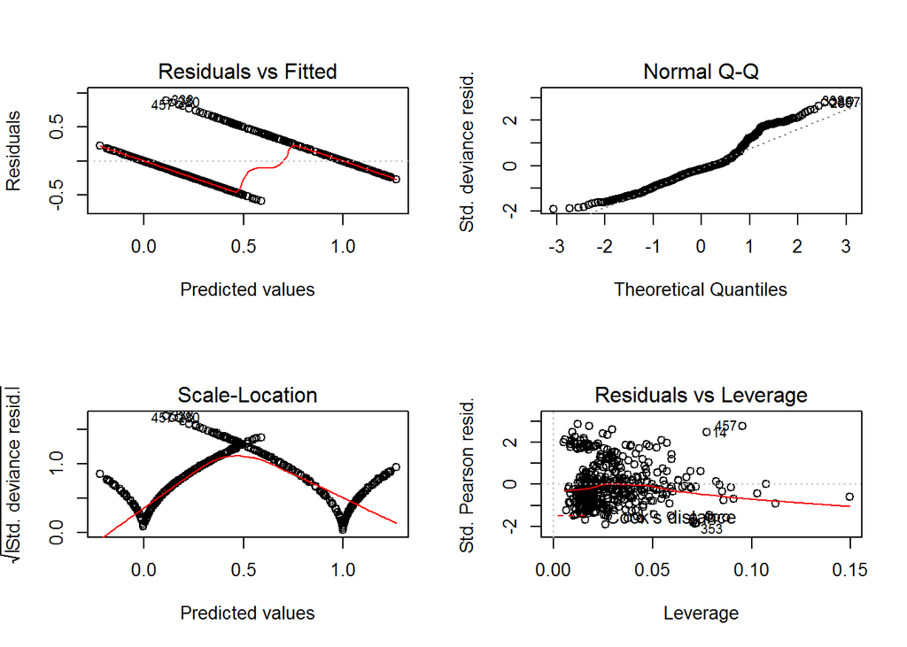

```r
par(mfrow=c(2,2))
plot(fit)
```

### Conclusion:

Simple regression model using glm package shows that the p value for zn,indus,chas, rm,dis, tax, ptratio,black ,lstat are more than the significance value of 0.05, so they are not contributing much to the target (independent variable)

So, lets move to the logistic regression for binomial distribution where we can see the variables interdependent on the independent variable target and get teh best fit subset of the crime dataset

### Using Logistics regression for a better results as

```r
crimetarget <- glm(target~., family=binomial(link='logit'),data=crime)


summary(crimetarget)
```

```
##
## Call:
## glm(formula = target ~ ., family = binomial(link = "logit"),
##     data = crime)
##
## Deviance Residuals:
##     Min       1Q   Median       3Q      Max
## -2.2854  -0.1372  -0.0017   0.0020   3.4721
##
## Coefficients:
##               Estimate Std. Error z value Pr(>|z|)
## (Intercept) -36.839521   7.028726  -5.241 1.59e-07 ***
## zn           -0.061720   0.034410  -1.794 0.072868 .
## indus        -0.072580   0.048546  -1.495 0.134894
## chas          1.032352   0.759627   1.359 0.174139
## nox          50.159513   8.049503   6.231 4.62e-10 ***
## rm           -0.692145   0.741431  -0.934 0.350548
## age           0.034522   0.013883   2.487 0.012895 *
## dis           0.765795   0.234407   3.267 0.001087 **
## rad           0.663015   0.165135   4.015 5.94e-05 ***
## tax          -0.006593   0.003064  -2.152 0.031422 *
## ptratio       0.442217   0.132234   3.344 0.000825 ***
## black        -0.013094   0.006680  -1.960 0.049974 *
## lstat         0.047571   0.054508   0.873 0.382802
## medv          0.199734   0.071022   2.812 0.004919 **
## ---
## Signif. codes:  0 '***' 0.001 '**' 0.01 '*' 0.05 '.' 0.1 ' ' 1
##
## (Dispersion parameter for binomial family taken to be 1)
##
##     Null deviance: 645.88  on 465  degrees of freedom
## Residual deviance: 186.15  on 452  degrees of freedom
## AIC: 214.15
##
## Number of Fisher Scoring iterations: 9
```

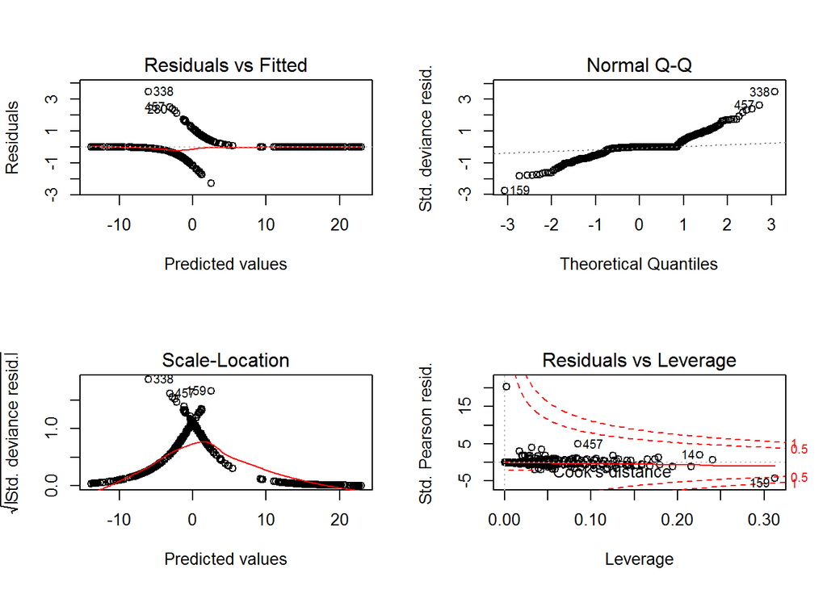

```r
par(mfrow=c(2,2))
plot(crimetarget)
```

### Conclusion:

We found that variables like zn, indus, chas,rm and lstat are not statistically significant due to their p-value being greater than statiscally accepted p-value of 0.05, So we have a scope to refine the model without these variables and repeat the best fit logistic regression and build a preditive model.

**Interpretations:**

Note that the Null **deviance** is 645.88, which implies that if all other parameters are held constant(control or not included), the estimate would be 645.88, while the Residual deviance of 186.15 means with the imclusion of other estimator, we expect the deviance to be 186.14. Also we should be talking about AIC which is 214,15 and signifies the best fit quality of the model compared to other similar model available. If we are comparing with other models, best model should have lowest deviance and AIC value.

So lets move forward with cleaning up the crime dataset with those variable which are not contributing to the target variable and arrive to the next best fit model.

*NB: The greater the difference between the Null deviance and Residual deviance, the better.

Lets confirm this by running the Analysis of Variance (ANOVA) on crimetarget dataset to confirm if we have concluded the significance of varaibles correctly or not.

```r
anova(crimetarget, test="Chisq")
```

```
## Analysis of Deviance Table
##
## Model: binomial, link: logit
##
## Response: target
##
## Terms added sequentially (first to last)
##
##
##         Df Deviance Resid. Df Resid. Dev  Pr(>Chi)
## NULL                      465     645.88
## zn       1  127.411       464     518.46 < 2.2e-16 ***
## indus    1   86.433       463     432.03 < 2.2e-16 ***
## chas     1    1.274       462     430.76  0.258981
## nox      1  150.804       461     279.95 < 2.2e-16 ***
## rm       1    6.755       460     273.20  0.009349 **
## age      1    0.217       459     272.98  0.641515
## dis      1    7.981       458     265.00  0.004727 **
## rad      1   53.018       457     211.98 3.305e-13 ***
## tax      1    5.562       456     206.42  0.018355 *
## ptratio  1    5.657       455     200.76  0.017388 *
## black    1    4.558       454     196.21  0.032774 *
## lstat    1    0.916       453     195.29  0.338509
## medv     1    9.144       452     186.15  0.002496 **
## ---
## Signif. codes:  0 '***' 0.001 '**' 0.01 '*' 0.05 '.' 0.1 ' ' 1
```

### Conclusion:

The Analysis of Variance tells a different story, it shows that the chas, age and lstat has no significance and rest all are contributing towards target variable. So lets run the best fit model keeping significant variables.

```r
crime2 <- subset(crime, select = -c(zn,indus,chas,rm,lstat))

crimetarget2 <- glm(target~., family=binomial(link='logit'),data=crime2)
summary(crimetarget2)
```

```
##
## Call:
## glm(formula = target ~ ., family = binomial(link = "logit"),
##     data = crime2)
##
## Deviance Residuals:
##      Min        1Q    Median        3Q       Max
## -2.42422  -0.19292  -0.01400   0.00279   3.06740
##
## Coefficients:
##               Estimate Std. Error z value Pr(>|z|)
## (Intercept) -32.301655   6.382694  -5.061 4.17e-07 ***
## nox          42.160350   6.674149   6.317 2.67e-10 ***
## age           0.031017   0.010681   2.904 0.003684 **
## dis           0.437803   0.172533   2.538 0.011165 *
## rad           0.703446   0.140296   5.014 5.33e-07 ***
## tax          -0.008744   0.002611  -3.348 0.000813 ***
## ptratio       0.395580   0.112482   3.517 0.000437 ***
## black        -0.012490   0.006760  -1.848 0.064662 .
## medv          0.101177   0.034116   2.966 0.003020 **
## ---
## Signif. codes:  0 '***' 0.001 '**' 0.01 '*' 0.05 '.' 0.1 ' ' 1
##
## (Dispersion parameter for binomial family taken to be 1)
##
##     Null deviance: 645.88  on 465  degrees of freedom
## Residual deviance: 198.28  on 457  degrees of freedom
## AIC: 216.28
##
## Number of Fisher Scoring iterations: 9
```

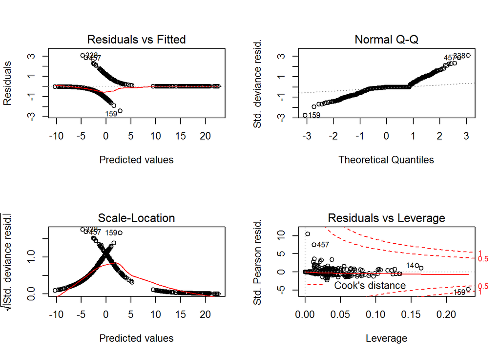

```r
par(mfrow=c(2,2))
plot(crimetarget2)
```

```r
anova(crimetarget2, test="Chisq")
```

```
## Analysis of Deviance Table
##
## Model: binomial, link: logit
##
## Response: target
##
## Terms added sequentially (first to last)
##
##
##         Df Deviance Resid. Df Resid. Dev  Pr(>Chi)
## NULL                      465     645.88
## nox      1   353.86       464     292.01 < 2.2e-16 ***
## age      1     1.39       463     290.63  0.238898
## dis      1     1.94       462     288.68  0.163583
## rad      1    54.52       461     234.17 1.542e-13 ***
## tax      1    16.00       460     218.17 6.344e-05 ***
## ptratio  1     5.77       459     212.40  0.016304 *
## black    1     3.91       458     208.49  0.048017 *
## medv     1    10.22       457     198.28  0.001393 **
## ---
## Signif. codes:  0 '***' 0.001 '**' 0.01 '*' 0.05 '.' 0.1 ' ' 1
```

## Conclusion:

age, dis are not significantly contributing to the target variable as it’s p value is more than the significance value, so lets remove that from the next iteration

```r
crime3 <- subset(crime2, select = -c(age, dis))

crimetarget3 <- glm(target~., family=binomial(link='logit'),data=crime3)
summary(crimetarget3)
```

```
##
## Call:
## glm(formula = target ~ ., family = binomial(link = "logit"),
##     data = crime3)
##
## Deviance Residuals:
##      Min        1Q    Median        3Q       Max
## -2.52073  -0.24712  -0.01736   0.00305   2.70746
##
## Coefficients:
##               Estimate Std. Error z value Pr(>|z|)
## (Intercept) -23.484353   4.765303  -4.928 8.30e-07 ***
## nox          37.380393   4.858387   7.694 1.43e-14 ***
## rad           0.702331   0.136014   5.164 2.42e-07 ***
## tax          -0.008810   0.002505  -3.517 0.000436 ***
## ptratio       0.328240   0.109335   3.002 0.002681 **
## black        -0.012860   0.006780  -1.897 0.057861 .
## medv          0.059285   0.028766   2.061 0.039309 *
## ---
## Signif. codes:  0 '***' 0.001 '**' 0.01 '*' 0.05 '.' 0.1 ' ' 1
##
## (Dispersion parameter for binomial family taken to be 1)
##
##     Null deviance: 645.88  on 465  degrees of freedom
## Residual deviance: 209.80  on 459  degrees of freedom
## AIC: 223.8
##
## Number of Fisher Scoring iterations: 9
```

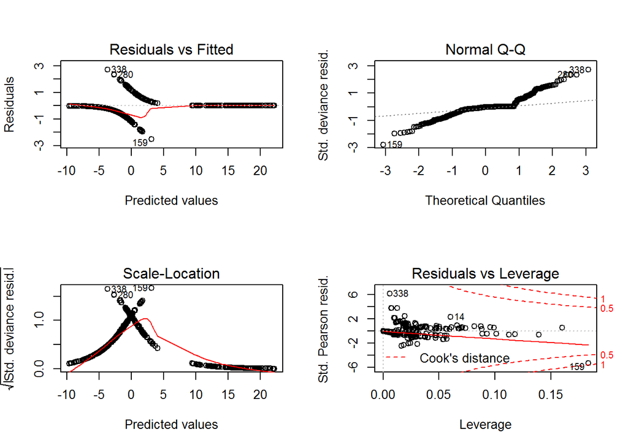

```r
par(mfrow=c(2,2))
plot(crimetarget3)
```

```r
anova(crimetarget3, test="Chisq")
```

```
## Analysis of Deviance Table
##
## Model: binomial, link: logit
##
## Response: target
##
## Terms added sequentially (first to last)
##
##
##         Df Deviance Resid. Df Resid. Dev  Pr(>Chi)
## NULL                      465     645.88
## nox      1   353.86       464     292.01 < 2.2e-16 ***
## rad      1    52.50       463     239.51   4.3e-13 ***
## tax      1    15.04       462     224.47 0.0001053 ***
## ptratio  1     5.77       461     218.70 0.0162983 *
## black    1     4.34       460     214.36 0.0372956 *
## medv     1     4.57       459     209.80 0.0325981 *
## ---
## Signif. codes:  0 '***' 0.001 '**' 0.01 '*' 0.05 '.' 0.1 ' ' 1
```

### Conclusion:

crimetarget3 model has nox,black, rad, tax, ptratio and medv as the significant variables and contrbuting to the target as key variable predicting crime in that area

## Predictive model for crimetarget model

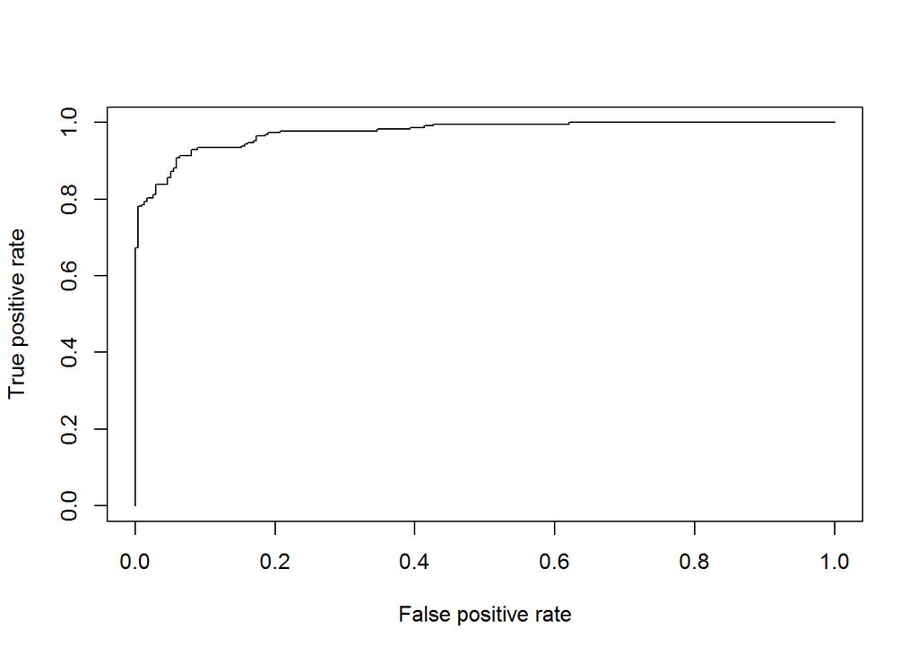

```r
pred <- predict(crimetarget, type="response")
pred2 <- prediction(pred, crime$target)
pred3 <- performance(pred2, measure = "tpr", x.measure = "fpr")
plot(pred3)
```

Above is the plot for Sensitivity and Specitivity for the city target, while the value below is it AUC.

```r
auc <- performance(pred2, measure = "auc")
auc <- auc@y.values[[1]]
auc
```

```
## [1] 0.9752732
```

> Predictions and Accuracy for crimetarget model

```r
target_predicts <- predict(crimetarget,newdata=subset(crime,select=c(1,2,3,4,5,6,7,8,9,10,11,12,13,14)),type='response')
target_predicts <- ifelse(target_predicts > 0.5,1,0)

attach(crime)

CM1<-table(target_predicts, target)
Pos_Pos=CM1[1,1]
Pos_Neg=CM1[1,2]
Neg_Pos=CM1[2,1]
Neg_Neg=CM1[2,2]

Specificity= Neg_Neg/(Pos_Neg+Neg_Neg)
Sensitivity= Pos_Pos/(Pos_Pos+Neg_Pos)
Pos_Pred_Val= Pos_Pos/(Pos_Pos+Pos_Neg)
Neg_Pred_Val=Neg_Neg/(Neg_Pos+Neg_Neg)

misClasificError <- mean(target_predicts != target)
Accuracy=1-misClasificError

print(paste('Accuracy',1-misClasificError))
```

```
## [1] "Accuracy 0.924892703862661"
```

```r
BestFitModel1<- data.frame(auc,Specificity,Sensitivity,Accuracy,Pos_Pred_Val,Neg_Pred_Val)
```

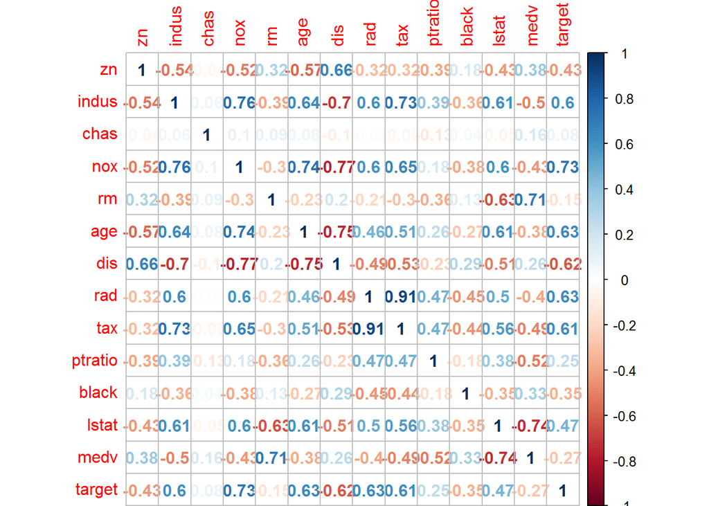

```r
M <- cor(crime)
corrplot(M, method="number")
```

## Predictive model for crimetarget2 model

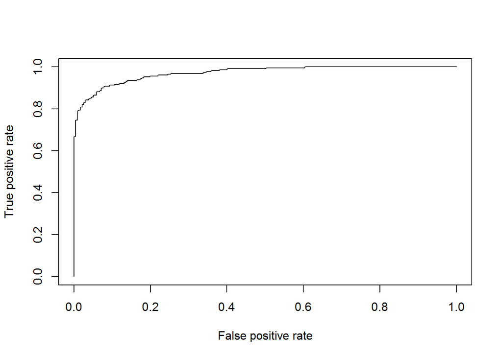

```r
pred <- predict(crimetarget2, type="response")
pred2 <- prediction(pred, crime$target)
pred3 <- performance(pred2, measure = "tpr", x.measure = "fpr")
plot(pred3)
```

Above is the plot for Sensitivity and Specitivity for the city target, while the value below is it AUC.

```r
auc <- performance(pred2, measure = "auc")
auc <- auc@y.values[[1]]
auc
```

```
## [1] 0.9712196
```

> Predictions and Accuracy for crimetarget2 model

```r
target_predicts <- predict(crimetarget2,newdata=crime,type='response')
target_predicts <- ifelse(target_predicts > 0.5,1,0)

attach(crime)
CM1<-table(target_predicts, target)
Pos_Pos=CM1[1,1]
Pos_Neg=CM1[1,2]
Neg_Pos=CM1[2,1]
Neg_Neg=CM1[2,2]

Specificity= Neg_Neg/(Pos_Neg+Neg_Neg)
Sensitivity= Pos_Pos/(Pos_Pos+Neg_Pos)
Pos_Pred_Val= Pos_Pos/(Pos_Pos+Pos_Neg)
Neg_Pred_Val=Neg_Neg/(Neg_Pos+Neg_Neg)

misClasificError <- mean(target_predicts != target)
Accuracy=1-misClasificError

print(paste('Accuracy',1-misClasificError))
```

```
## [1] "Accuracy 0.912017167381974"
```

```r
BestFitModel2<- data.frame(auc,Specificity,Sensitivity,Accuracy,Pos_Pred_Val,Neg_Pred_Val)
```

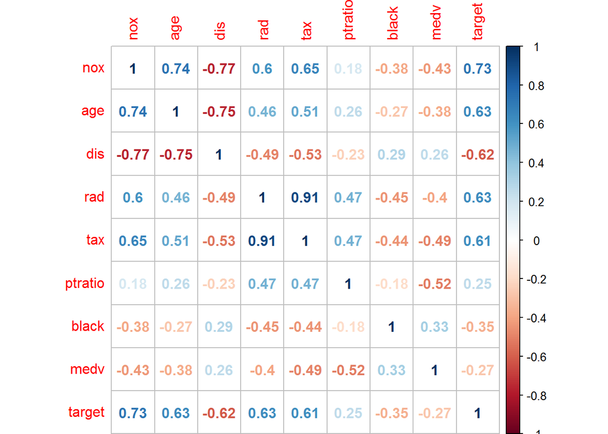

```r
M <- cor(crime2)
corrplot(M, method="number")
```

## Predictive model for crimetarget3 model

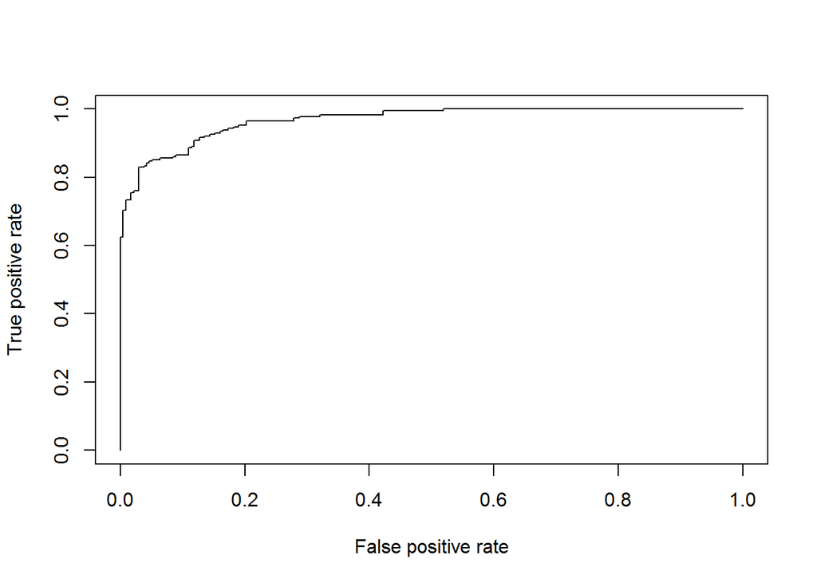

```r
pred <- predict(crimetarget3, type="response")
pred2 <- prediction(pred, crime$target)
pred3 <- performance(pred2, measure = "tpr", x.measure = "fpr")
plot(pred3)
```

Above is the plot for Sensitivity and Specitivity for the city target, while the value below is it AUC.

```r
auc <- performance(pred2, measure = "auc")
auc <- auc@y.values[[1]]
auc
```

```
## [1] 0.9676266
```

> Predictions and Accuracy.

```r
target_predicts <- predict(crimetarget3,newdata=crime,type='response')
target_predicts <- ifelse(target_predicts > 0.5,1,0)

attach(crime)
CM1<-table(target_predicts, target)
Pos_Pos=CM1[1,1]
Pos_Neg=CM1[1,2]
Neg_Pos=CM1[2,1]
Neg_Neg=CM1[2,2]

Specificity= Neg_Neg/(Pos_Neg+Neg_Neg)
Sensitivity= Pos_Pos/(Pos_Pos+Neg_Pos)
Pos_Pred_Val= Pos_Pos/(Pos_Pos+Pos_Neg)
Neg_Pred_Val=Neg_Neg/(Neg_Pos+Neg_Neg)

misClasificError <- mean(target_predicts != target)
Accuracy=1-misClasificError

print(paste('Accuracy',1-misClasificError))
```

```
## [1] "Accuracy 0.888412017167382"
```

```r
BestFitModel3<- data.frame(auc,Specificity,Sensitivity,Accuracy,Pos_Pred_Val,Neg_Pred_Val)
```

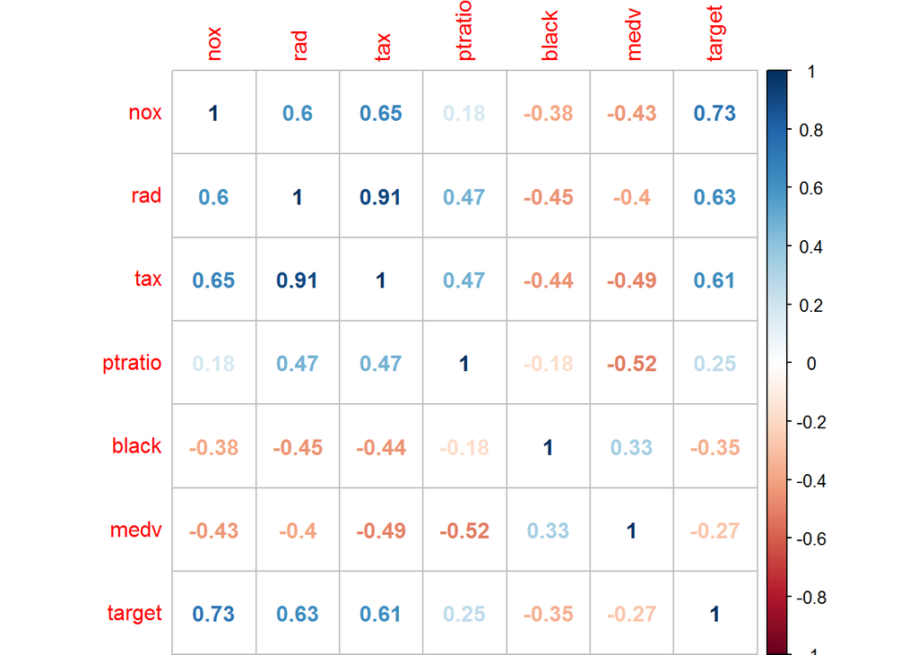

```r
M <- cor(crime3)
corrplot(M, method="number")
```

## Compare the Models to choose the best

```r
CompareBestFitModel=rbind(BestFitModel1,BestFitModel2,BestFitModel3)
colnames(CompareBestFitModel)=c("AUC","Specificity","Sensitivity","Accuracy","Pos_Pred_Val","Neg_Pred_Val")
rownames(CompareBestFitModel)=c("Model1","Model2","Model3")
CompareBestFitModel
```

```
##              AUC Specificity Sensitivity  Accuracy Pos_Pred_Val
## Model1 0.9752732   0.9126638   0.9367089 0.9248927    0.9173554
## Model2 0.9712196   0.8995633   0.9240506 0.9120172    0.9049587
## Model3 0.9676266   0.8602620   0.9156118 0.8884120    0.8714859
##        Neg_Pred_Val
## Model1    0.9330357
## Model2    0.9196429
## Model3    0.9078341
```

**Conclusion:**

From the genaral logit regression model,

${ y=\quad }\frac { { e }^{ { \beta x\prime }_{ i } } }{ 1+\quad { e }^{ { \beta x\prime }_{ i } } }$

,where ${\quad x\prime}_{i} \quad$ are

nox, rad, tax, pratio, black, medv.

From the above analysis, we can deduce that the AUC ( Area Under Curve) for all the three models are very close to 1, which indicate that the model is very good and that the true positive is higher than the true negative.

**Recommendation**

We therefore recommend that, the nox, rad, tax, pratio, black and medv contributed significantly to the increasing crime rate of the city under observation.